# Carrera la luz 2022

### Tiempos de carrera

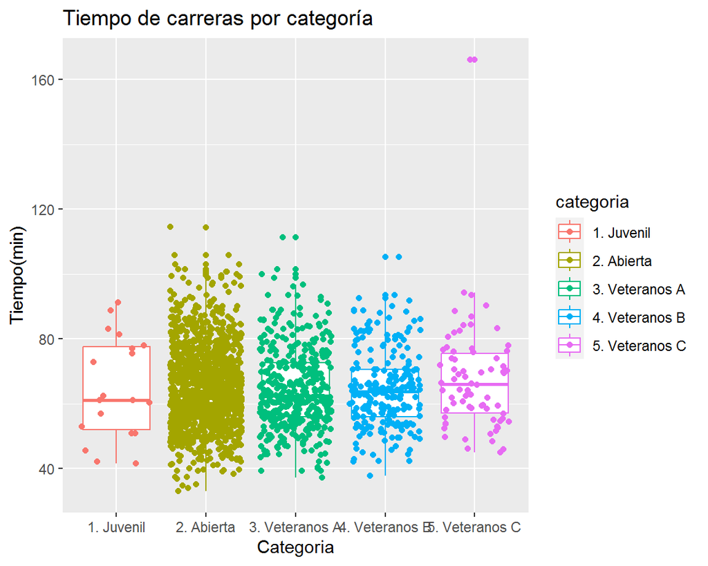

### Análisis general

**Los resultados presentados corresponden a la carrera de la luz llevada a cabo en el año 2022, en las calles y parques de ciudades del suroccidente colombiano y tiene como objetivo formar deportistas recreativos y profesionales en pro de tener una vida saludable.**

La carrera tenia una distancia de 10,07 kilometros, participaron 1922 atletas de los cuales el 39% fueron mujeres y el 61% fueron hombres el tiempo ganador fue de 33,1 minutos y el tiempo promedio utilizado en la carrera fue de 65.3 minutos.

### Hombres por categoría

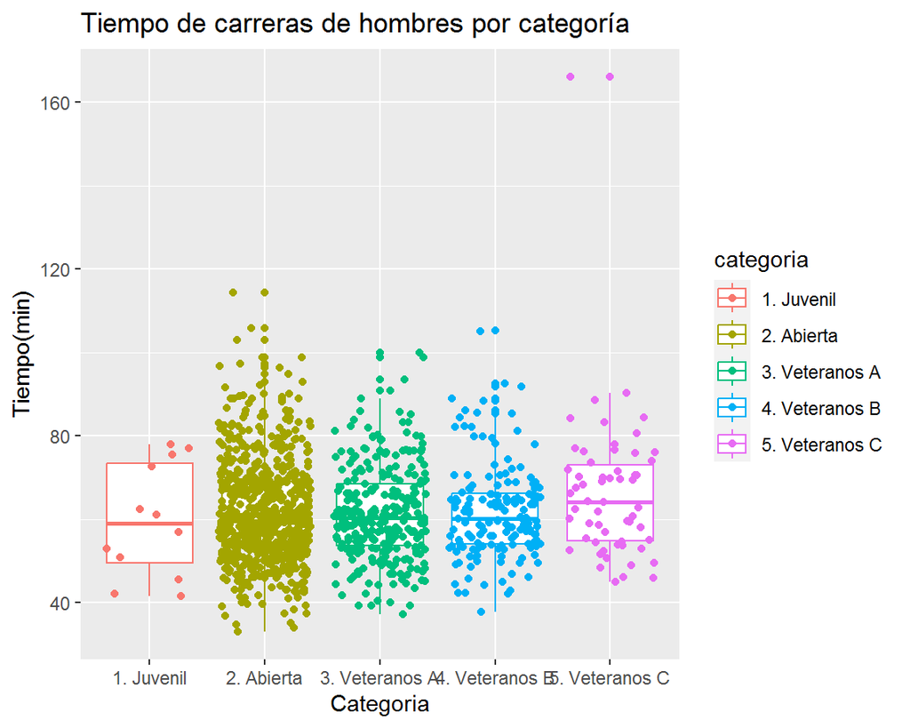